# 최종html

## 빅데이터를 활용한 경제 및 금융문제 분석 최종 html

## SVM 모형을 활용한 계통한계가격(SMP) 예측 분석

2019224213  
자원환경공학과  
석박사통합과정 5기  
이정환

### 1. 연구 배경 및 목적

- 선진국을 중심으로 전력시장은 독점시장에서 규제완화와 구조개편을 통한 경쟁적인 시장으로 변화 중
- 제한적이긴 하지만 1999~2002년 한국전력은 발전부문을 6개사로 분리하여 경쟁을 도입
- 발전사들은 시장원리에 따라 전략적으로 발전하여 많은 이익을 얻기 위한 전략이 필요
- 따라서 SMP 예측은 시장참여자에게 전략을 세우는데 중요한 지표가 됨
- 일반적으로 경제학에 많이 사용되는 선형 모형이 아닌 Support vector machine(SVM) 모형을 사용하여 SMP 가격을 예측

### 2. Support vector machine(SVM)

- 머신러닝 모형중 SVM 모형은 ANN에 비해 과적합이 나타나지 않으며 Local minimum값이 나타나지 않고, 많은 예측 불가능한 샘플밖 데이터를 피할 수 있다는 장점들이 있음
- ANN 보다 더 좋은 결과 값을 얻을 수 있음
- 강건한 예측 모델
- ANN보다 조정 불가능한 매개변수가 적기때문에 사용에 유리

### 3. Data

- 예측 대상인 전력 가격은 한국 전력시장의 SMP 가격을 사용
- Jeong(2006)에 따라 현재 SMP에 영향을 미치는 변수로 과거 SMP와 전력수요를 사용
- 전력수요는 한국남부발전의 전력수급량을 사용
- Open API 데이터를 사용
- 일별 Data를 사용하여 예측

**표 1. 자료 통계량**

| 변수 | 평균 | 표준편차 |
| --- | --- | --- |
| 계통한계가격(SMP) | 68.71 | 11.06 |
| 전력수요 | 68098 | 5109 |

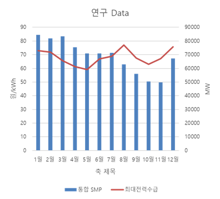

### 4. 분석결과

### 4.1 SMP를 독립변수로 사용

- 다음은 예측 결과값을 출력하는 코드이다.
- 12월 21시 0시~15시의 시간별 SMP를 이용해 예측한 결과이다. 결정계수를 사용하여 각각의 신뢰도를 판단하였을 시, SVM: 0.38, LR: -0.12로 본 예측은 타당하지 않은 결과로 판단되었다.

**표 2. SMP를 독립변수로 사용한 예측결과**

| 거래시간 | SVM(KRW) | LR(KRW) | 실제값(KRW) |  |
| --- | --- | --- | --- | --- |
| 16 | 146 | 145 | 147 |  |
| 17 | 146 | 145 | 147 |  |
| 18 | 146 | 145 | 147 |  |
| 19 | 146 | 145 | 147 |  |
| 20 | 141 | 146 | 145 |  |
| 21 | 159 | 146 | 141 |  |
| 22 | 161 | 146 | 142 |  |
| 23 | 161 | 146 | 142 |  |

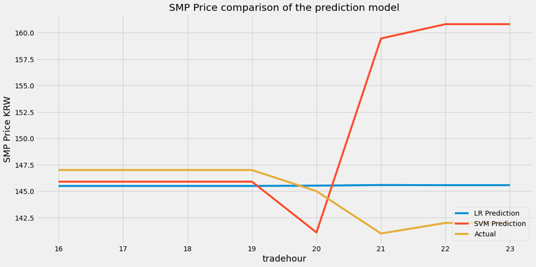

**그림 1. SMP를 독립변수로 사용한 예측 그래프**

### 4.2. SMP와 전력 수요를 독립변수로 사용

- 다음은 일반 데이터를 사용해 일별 SMP 예측 결과값을 출력하는 코드이다.
- 결정계수로 신뢰도를 판단하였을 시, SVM: -0.26, LR -2.01로 또한 예측력이 타당하지 않는 것으로 나타났다.

**표 3. SMP와 전력수요를 독립변수로 사용한 예측결과**

[output not shown]

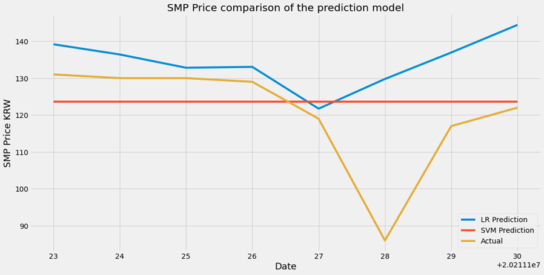

**그림 2. SMP와 전력수요를 독립변수로 사용한 예측 그래프**

### 5. 결론

- 독립변수로 SMP를 사용하여 단기 SMP를 시간별로 예측하여 실제값 및 LR 예측치와 비교해보았다.
- 독립변수로 SMP와 전력수요를 사용하여 일별 데이터를 예측하여 이 또한 실제값 및 LR 예측치와 비교해보았다.
- 두 분석 모두 예측력이 떨어지는 것으로 나타났으나, 일별 분석보다는 시간별 분석에서 결정계수값이 높게 나타났다.
- 단기예측에서 더 정확도를 보이는 것으로 판단되므로 중장기 전력가격 예측에 대해서는 설명력을 높일 있는 방안에 대하여 검토되어야 한다.
- 또한 SMP와 전력 수요 외에 적합한 설명력을 가질 수 있는 결정인자들이 무엇이 있을지 추가적으로 검토되어야 한다.

### 6. Code

### 6.1. 독립변수로 SMP를 사용(Open API 데이터를 사용)

[Code]

```
import requests
from bs4 import BeautifulSoup
import pandas as pd
import matplotlib.pyplot as plt
import quandl
import numpy as np
from sklearn import svm, datasets
from sklearn.linear_model import LinearRegression
from sklearn.svm import SVR
from sklearn.model_selection import train_test_split

# 인증 Key 설정
encodingKey = "인증키 입력"
decodingKey = "인증키 입력"

# smp
url = 'https://openapi.kpx.or.kr/openapi/smp1hToday/getSmp1hToday'
params ={'serviceKey' : decodingKey, 'areaCd' : '1'}
response = requests.get(url, params=params)
soup = BeautifulSoup(response.text, "html.parser")

#PANDAS를 통해 불러오기
rows = soup.findAll('item')
rowList = []
nameList = []
columnList = []

rowsLen = len(rows)
for i in range(0, rowsLen):
    columns = rows[i].find_all()

    columnsLen = len(columns)
    for j in range(0, columnsLen):
        if i == 0:
            nameList.append(columns[j].name)
        eachColumn = columns[j].text
        columnList.append(eachColumn)
    rowList.append(columnList)
    columnList = []

df = pd.DataFrame(rowList, columns=nameList)

#df = df.drop(['tradeday', 'areacd'], axis=1) # drop
df = df.set_index('tradehour') # index를 date로 설정
df = df.astype(np.float)
df = df.astype(np.int)
df = df[['smp']]   # smp만 사용하게끔 설정
df

# Forecasing number set
forecast_out = 8
df['Prediction'] = df[['smp']].shift(-forecast_out)
#df.tail()

###Create the independent data set (X) #####
#Convert the dataframe to a numpy array
X = np.array(df.drop(['Prediction'],1)) #drop prediction column cause indepent variable

# Remove the last 'n' rows
X = X[:-forecast_out] #excluding the last 'n' days

### Create the dependent data set (y) #####
# Convert the dataframe to a numpy array (All of the values including the NaN's)
y = np.array(df['Prediction'])

# Get all of the y values except the last 'n' rows
y = y[:-forecast_out]

# Split the data into 80% training and 20% testing
x_train, x_test, y_train, y_test = train_test_split(X, y, test_size=0.2)

# Create and train the Support Vector Machine (Regressor)
svr_rbf = SVR(kernel='rbf', C=1e3, gamma=0.1)
svr_rbf.fit(x_train, y_train)

# Create and the Linear Regression Model
lr = LinearRegression()
# Train the model
lr.fit(x_train, y_train)

# Testing Model: Score returns the coefficient of determination R^2 of the prediction
# The best possible score is 1.0
svm_confidence = svr_rbf.score(x_test, y_test)
print("svm confidence:", svm_confidence)

# Testing Model: Score returns the coefficient of determination R^2 of the prediction
# The best possible score is 1.0
lr_confidence = lr.score(x_test, y_test)
print("lr confidence:", lr_confidence)

x_forecast = np.array(df.drop(['Prediction'], 1))[-forecast_out:]
#print(x_forecast)

# Print linear regression model the prediction for the next 'n' days
lr_prediction = lr.predict(x_forecast)
#print(lr_prediction)

# Print Support Vector regressor model the predictions for the nest 'n' days
svm_prediction = svr_rbf.predict(x_forecast)
#print(svm_prediction)

df = df[-forecast_out:]
df_forecast = df.drop(['Prediction', 'smp'],1)
df_forecast['SVM Prediction'] = svm_prediction
df_forecast['LR Prediction'] = lr_prediction
actual = np.array(df['smp'])
df_forecast['Actual'] = actual
df_forecast

# Figure
plt.style.use('fivethirtyeight')
plt.figure(figsize=(16,8))
plt.title('SMP Price comparison of the prediction model')
plt.plot(df_forecast['LR Prediction'])
plt.plot(df_forecast['SVM Prediction'])
plt.plot(df_forecast['Actual'])
plt.ylabel('SMP Price KRW', fontsize=18)
plt.xlabel('tradehour', fontsize=18)
plt.legend(['LR Prediction', 'SVM Prediction', 'Actual'], loc='lower right')
plt.show()
```

### 6.2. 독립변수로 SMP와 전력수요를 사용(일반 데이터를 사용)

[Code]

```
import requests
from bs4 import BeautifulSoup
import pandas as pd
import matplotlib.pyplot as plt
import quandl
import numpy as np
from sklearn import svm, datasets
from sklearn.linear_model import LinearRegression
from sklearn.svm import SVR
from sklearn.model_selection import train_test_split

#파일 경로 설정
Location = 'G:/내 드라이브/Coursework/2021-2/빅데이터를활용한경제및금융문제분석'
File = 'data.xlsx'


# 추출 행, 열 선언
#Row = 10
#Column = 5

# 추출 및 변환 코드
data_pd = pd.read_excel('{}/{}'.format(Location, File))
data_np = pd.DataFrame.to_numpy(data_pd)

# 출력
#print(data_pd)
#print(data_np[Row][Column])

df = data_pd
df = df.set_index('date') # index를 date로 설정

df = df.astype(np.float)
df = df.astype(np.int)

df
# Forecasing number set
forecast_out = 8
df['Prediction'] = df[['smp']].shift(-forecast_out)
#df.tail()

###Create the independent data set (X) #####
#Convert the dataframe to a numpy array
X = np.array(df.drop(['Prediction'],1)) #drop prediction column cause indepent variable

# Remove the last 'n' rows
X = X[:-forecast_out] #excluding the last 'n' days

### Create the dependent data set (y) #####
# Convert the dataframe to a numpy array (All of the values including the NaN's)
y = np.array(df['Prediction'])

# Get all of the y values except the last 'n' rows
y = y[:-forecast_out]

# Split the data into 80% training and 20% testing
x_train, x_test, y_train, y_test = train_test_split(X, y, test_size=0.2)

# Create and train the Support Vector Machine (Regressor)
svr_rbf = SVR(kernel='rbf', C=1e3, gamma=0.1)
svr_rbf.fit(x_train, y_train)

# Create and the Linear Regression Model
lr = LinearRegression()
# Train the model
lr.fit(x_train, y_train)

# Testing Model: Score returns the coefficient of determination R^2 of the prediction
# The best possible score is 1.0
svm_confidence = svr_rbf.score(x_test, y_test)
print("svm confidence:", svm_confidence)

# Testing Model: Score returns the coefficient of determination R^2 of the prediction
# The best possible score is 1.0
lr_confidence = lr.score(x_test, y_test)
print("lr confidence:", lr_confidence)

x_forecast = np.array(df.drop(['Prediction'], 1))[-forecast_out:]
#print(x_forecast)

# Print linear regression model the prediction for the next 'n' days
lr_prediction = lr.predict(x_forecast)
#print(lr_prediction)

# Print Support Vector regressor model the predictions for the nest 'n' days
svm_prediction = svr_rbf.predict(x_forecast)
#print(svm_prediction)

df = df[-forecast_out:]
df_forecast = df.drop(['Prediction', 'smp'],1)
df_forecast['SVM Prediction'] = svm_prediction
df_forecast['LR Prediction'] = lr_prediction
actual = np.array(df['smp'])
df_forecast['Actual'] = actual
df_forecast
# Figure
plt.style.use('fivethirtyeight')
plt.figure(figsize=(16,8))
plt.title('SMP Price comparison of the prediction model')
plt.plot(df_forecast['LR Prediction'])
plt.plot(df_forecast['SVM Prediction'])
plt.plot(df_forecast['Actual'])
plt.ylabel('SMP Price KRW', fontsize=18)
plt.xlabel('Date', fontsize=18)
plt.legend(['LR Prediction', 'SVM Prediction', 'Actual'], loc='lower right')
plt.show()
```